# Series de tiempo: Inflación

Oscar García Cervantes - Taller de economía cuantitativa VI

viernes 03 de junio, 2022

# 1. Paqueterias

```r
library(forecast)
library(tidyverse)
library(tseries)
library(mFilter)
library(ggfortify)
library(aTSA)
```

# 2. Bases de datos

Para esta sesión utilizaremos las bases de datos de inflación y el Índice nacional de precios al consumidor (INPC) publicadas por el Instituto Nacional de Estadística y Geografía (INEGI). Tenemos dos bases de datos: La base `Inflacion_1970` es la de mayor amplitud y contiene datos mensuales de la inflación desde enero de 1970, la inflación interanual y la inflación acumulada anual.También, la base `Indice_mensual`, que contiene el INPC (base segunda quincena de 2018=100) de manera general y el índice subyacente y no subyacente de manera desagregada, las series para el periodo de 1982-01 a 2022-04.

```r
Inflacion_1970 <- read.csv("Inflación_1970.csv", header = TRUE)
Indice_mensual <- read.csv("Indice_mensual.csv", header = T)
```

# 3. Visualización de datos

Primero le damos estructura de series de tiempo a las series que analizaremos:

```r
Inflacion_mensual <- ts(Inflacion_1970$Inflación.mensual, start = c(1970, 1), frequency = 12)
Inflacion_mensual_inter <- ts(Inflacion_1970$Inflación.mensual.interanual, start = c(1970, 1), frequency = 12)
Indice_mensual_ts <- ts(Indice_mensual$Indice.general, start = c(1982, 1), frequency = 12)

print(Inflacion_mensual)
```

```
##        Jan   Feb   Mar   Apr   May   Jun   Jul   Aug   Sep   Oct   Nov   Dec
## 1970  0.76 -0.01  0.29  0.13  0.21  0.61  0.49  0.46  0.24  0.03  0.54  0.85
## 1971  0.99  0.41  0.38  0.51  0.21  0.45 -0.08  0.91  0.33  0.10  0.16  0.48
## 1972  0.44  0.31  0.55  0.63  0.20  0.74  0.38  0.66  0.46  0.07  0.65  0.34
## 1973  1.45  0.83  0.88  1.58  1.06  0.82  2.56  1.60  2.38  1.28  1.23  3.88
## 1974  3.58  2.26  0.77  1.36  0.79  0.99  1.45  1.06  1.13  1.98  2.78  0.78
## 1975  1.28  0.55  0.63  0.84  1.34  1.70  0.80  0.87  0.73  0.51  0.70  0.82
## 1976  1.93  1.87  0.98  0.70  0.70  0.40  0.85  0.96  3.41  5.63  4.52  2.51
## 1977  3.19  2.21  1.74  1.51  0.88  1.23  1.13  2.05  1.77  0.76  1.09  1.38
## 1978  2.22  1.44  1.04  1.11  0.98  1.38  1.70  1.00  1.14  1.21  1.03  0.85
## 1979  3.55  1.44  1.36  0.90  1.31  1.11  1.21  1.51  1.23  1.75  1.29  1.77
## 1980  4.88  2.31  2.06  1.75  1.63  1.98  2.79  2.07  1.11  1.51  1.73  2.62
## 1981  3.22  2.46  2.14  2.26  1.51  1.40  1.76  2.06  1.86  2.22  1.92  2.69
## 1982  4.97  3.93  3.65  5.42  5.62  4.82  5.15 11.22  5.34  5.18  5.06 10.68
## 1983 10.88  5.37  4.84  6.33  4.34  3.79  4.94  3.88  3.08  3.32  5.87  4.28
```

[output cut: 39 more lines]

A diferencia de las sesiones previas, para graficar series de tiempo con `ggplot2` utilizamos el comando `autoplot()`. Añadimos `ggplot2::` previo a `autoplot` porque el mismo comando también se encuentra en la paquetería forecast y así nos aseguramos que utilice la paquetería `ggplot2`.

Ahora visualisamos las series:

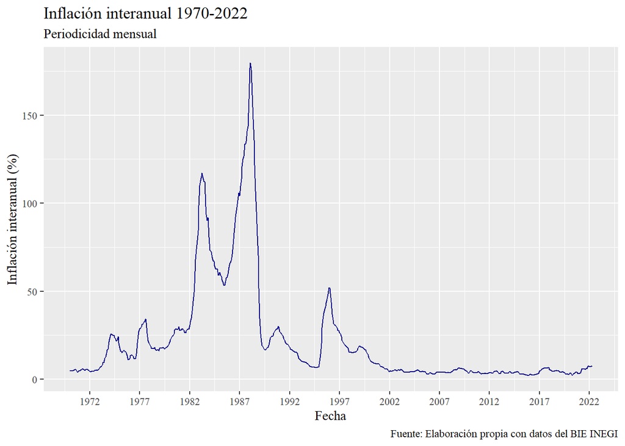

```r
ggplot2::autoplot(Inflacion_mensual_inter, ts.colour = "darkblue") +
     labs(title = "Inflación interanual 1970-2022",
          subtitle = "Periodicidad mensual",
          x = "Fecha",
          y = "Inflación interanual (%)",
          caption = "Fuente: Elaboración propia con datos del BIE INEGI") +
     theme_gray(base_family = "serif") +
     scale_x_date(date_breaks = "5 year", date_labels = "%Y")
```

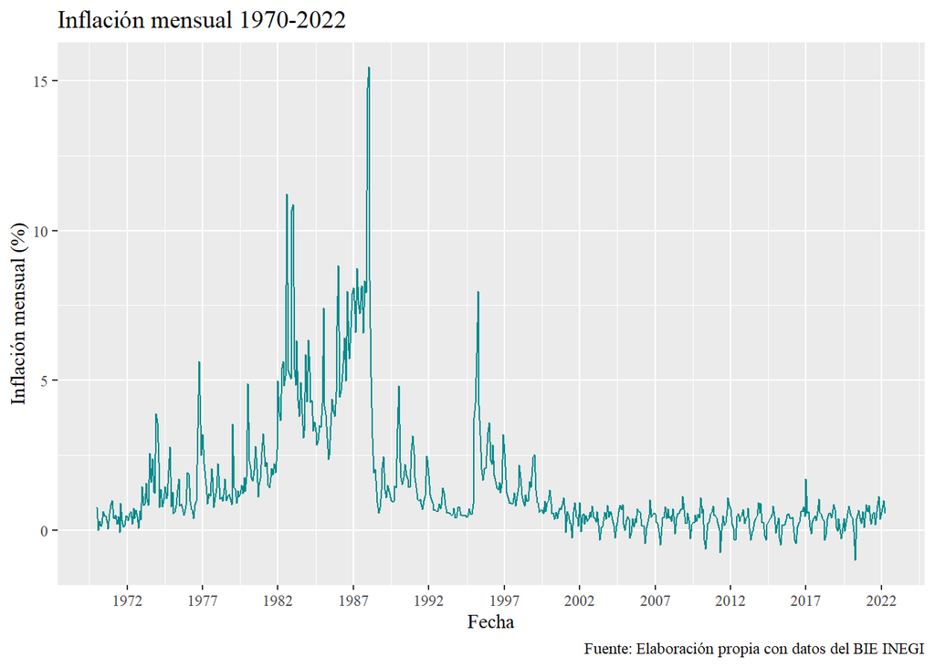

```r
ggplot2::autoplot(Inflacion_mensual, ts.colour = "cyan4") +
     labs(title = "Inflación mensual 1970-2022",
          x = "Fecha",
          y = "Inflación mensual (%)",
          caption = "Fuente: Elaboración propia con datos del BIE INEGI") +
     theme_gray(base_family = "serif") +
     scale_x_date(date_breaks = "5 year", date_labels = "%Y")
```

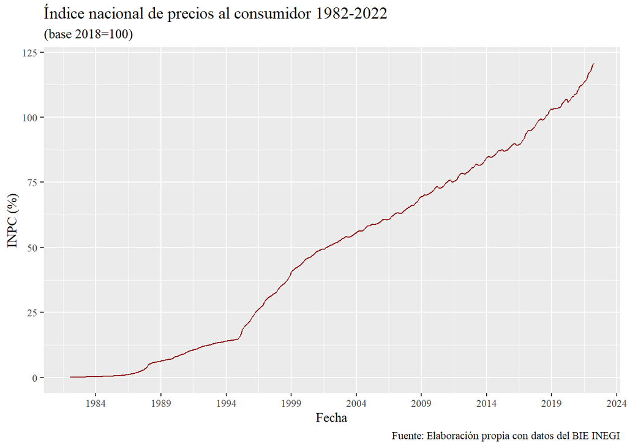

```r
ggplot2::autoplot(Indice_mensual_ts, ts.colour = "darkred") +
     labs(title = "Índice nacional de precios al consumidor 1982-2022",
          subtitle = "(base 2018=100)",
          x = "Fecha",
          y = "INPC (%)",
          caption = "Fuente: Elaboración propia con datos del BIE INEGI") +
     theme_gray(base_family = "serif") +
     scale_x_date(date_breaks = "5 year", date_labels = "%Y")
```

# 4. Componentes de las series de tiempo

Para elegir el método adecuado de pronóstico es útil separar las series de tiempo en una parte sistemática y una no sistemática. La parte sistemática se divide normalmente en tres componentes: nivel, tendencia y estacionalidad. La parte no sistemática se conoce normalmente como *ruido*.

El nivel describe los valores promedio de las series; la tendencia es el cambio de la serie de un periodo a otro; y la estacionalidad describe un comportamiento cíclico de corto plazo que puede observar varias veces en la serie. Algunas series no tienen tendencia o estacionalidad, pero todas tienen nivel.

Los componentes son comúnmente considerados como aditivos o multiplicativos.

**Aditivos:**
$$y_t=Nivel+Tendencia+Estacionalidad+Ruido$$

**Multiplicativos:**
$$y_t=Nivel*Tendencia*Estacionalidad*Ruido$$

# 5. Modelos de regresión

Los modelos los realizaremos para la serie `Indice_mensual_ts`.

## 5.1 Modelo de tendencia lineal

El modelo de tendencia lineal se representa de la siguiente manera:

$$y_t = \beta_0+\beta_1t+\epsilon$$
en este caso $y_t$ es el INPC, $\beta_0$ es el nivel, $\beta_1$ es la tendencia y $\epsilon$ es el ruido. La estacionalidad no se modela.

```r
m_tl <- tslm(Indice_mensual_ts ~ trend)
summary(m_tl)
```

```
##
## Call:
## tslm(formula = Indice_mensual_ts ~ trend)
##
## Residuals:
##      Min       1Q   Median       3Q      Max
## -11.2563  -1.8012  -0.3753   2.4548  13.7807
##
## Coefficients:
##               Estimate Std. Error t value Pr(>|t|)
## (Intercept) -13.951432   0.407366  -34.25   <2e-16 ***
## trend         0.256583   0.001456  176.28   <2e-16 ***
## ---
## Signif. codes:  0 '***' 0.001 '**' 0.01 '*' 0.05 '.' 0.1 ' ' 1
##
## Residual standard error: 4.474 on 482 degrees of freedom
## Multiple R-squared:  0.9847, Adjusted R-squared:  0.9847
## F-statistic: 3.107e+04 on 1 and 482 DF,  p-value: < 2.2e-16
```

```r
m_tl_s <- tslm(Indice_mensual_ts ~ trend + season)
summary(m_tl_s)
```

```
##
## Call:
## tslm(formula = Indice_mensual_ts ~ trend + season)
##
## Residuals:
##      Min       1Q   Median       3Q      Max
## -11.4196  -1.8918  -0.4011   2.2951  13.3157
##
## Coefficients:
##               Estimate Std. Error t value Pr(>|t|)
## (Intercept) -13.486449   0.788716 -17.099   <2e-16 ***
## trend         0.256580   0.001468 174.727   <2e-16 ***
## season2       0.008034   0.996824   0.008    0.994
## season3       0.038909   0.996828   0.039    0.969
## season4      -0.110956   0.996833  -0.111    0.911
## season5      -0.637090   1.003038  -0.635    0.526
## season6      -0.724368   1.003035  -0.722    0.471
## season7      -0.770673   1.003034  -0.768    0.443
## season8      -0.823971   1.003035  -0.821    0.412
## season9      -0.788019   1.003038  -0.786    0.432
## season10     -0.742125   1.003044  -0.740    0.460
## season11     -0.579715   1.003051  -0.578    0.564
## season12     -0.484783   1.003061  -0.483    0.629
## ---
## Signif. codes:  0 '***' 0.001 '**' 0.01 '*' 0.05 '.' 0.1 ' ' 1
##
## Residual standard error: 4.513 on 471 degrees of freedom
## Multiple R-squared:  0.9848, Adjusted R-squared:  0.9844
## F-statistic:  2545 on 12 and 471 DF,  p-value: < 2.2e-16
```

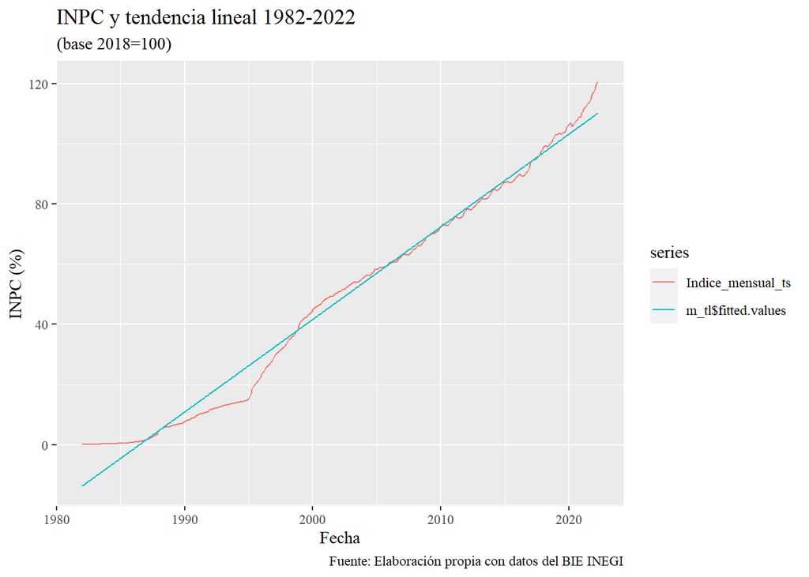

```r
mtl <- cbind(Indice_mensual_ts, m_tl$fitted.values)

ggplot2::autoplot(mtl) +
     labs(title = "INPC y tendencia lineal 1982-2022",
          subtitle = "(base 2018=100)",
          x = "Fecha",
          y = "INPC (%)",
          caption = "Fuente: Elaboración propia con datos del BIE INEGI") +
     theme_gray(base_family = "serif")
```

Como $\beta_1>0$ sabemos que existe tendencia lineal creciente.

## 5.2 Modelo de tendencia cuadrática

El modelo de tendencia cuadrática se representa de la siguiente manera:

$$y_t=\beta_0+\beta_1t+\beta_2t^2+\epsilon$$
Ahora realizamos la regresión:

```r
m_tc <- tslm(Indice_mensual_ts ~ trend + I(trend^2))
summary(m_tc)
```

```
##
## Call:
## tslm(formula = Indice_mensual_ts ~ trend + I(trend^2))
##
## Residuals:
##     Min      1Q  Median      3Q     Max
## -9.6223 -2.1244 -0.3339  2.6156  8.5142
##
## Coefficients:
##               Estimate Std. Error t value Pr(>|t|)
## (Intercept) -8.619e+00  5.197e-01  -16.58   <2e-16 ***
## trend        1.908e-01  4.949e-03   38.54   <2e-16 ***
## I(trend^2)   1.357e-04  9.882e-06   13.74   <2e-16 ***
## ---
## Signif. codes:  0 '***' 0.001 '**' 0.01 '*' 0.05 '.' 0.1 ' ' 1
##
## Residual standard error: 3.796 on 481 degrees of freedom
## Multiple R-squared:  0.989,  Adjusted R-squared:  0.989
## F-statistic: 2.168e+04 on 2 and 481 DF,  p-value: < 2.2e-16
```

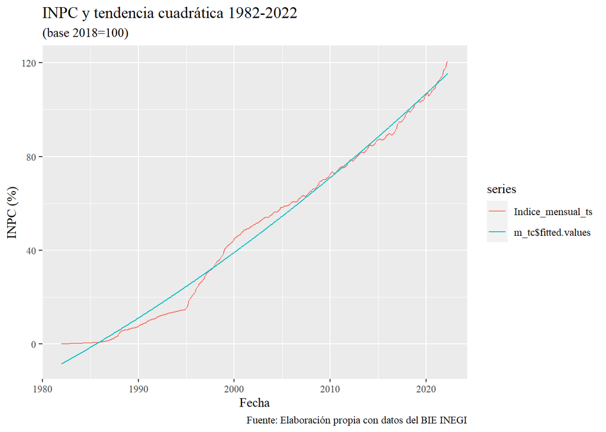

```r
mtc <- cbind(Indice_mensual_ts, m_tc$fitted.values)

ggplot2::autoplot(mtc) +
     labs(title = "INPC y tendencia cuadrática 1982-2022",
          subtitle = "(base 2018=100)",
          x = "Fecha",
          y = "INPC (%)",
          caption = "Fuente: Elaboración propia con datos del BIE INEGI") +
     theme_gray(base_family = "serif")
```

# 6. Modelos de suavizamiento

## 6.1 Medias móviles

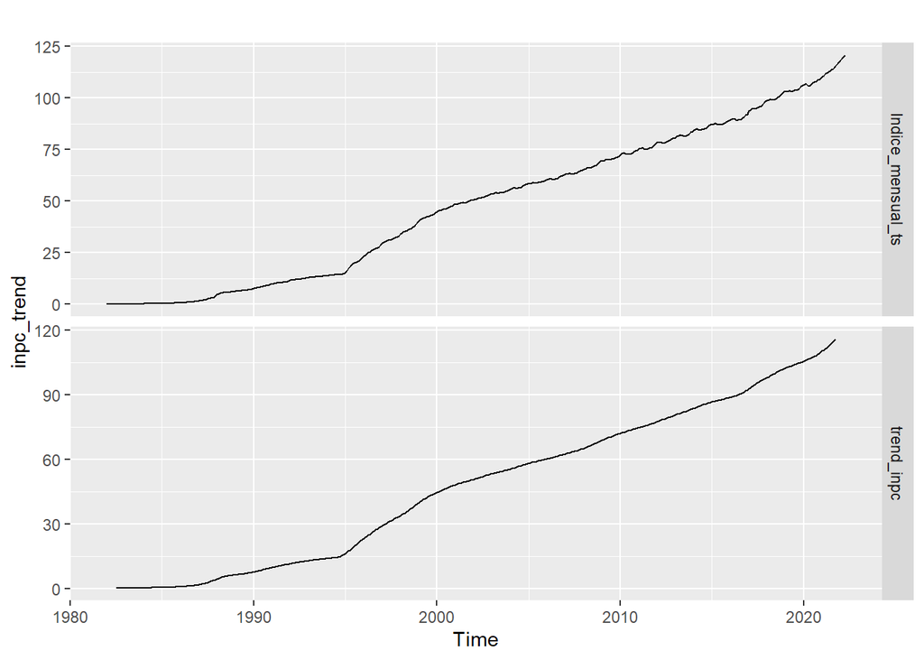

```r
# Tendencia
trend_inpc <- ma(Indice_mensual_ts, order = 12, centre = T)
inpc_trend <- cbind(Indice_mensual_ts, trend_inpc)
ggplot2::autoplot(inpc_trend, facets = T)
```

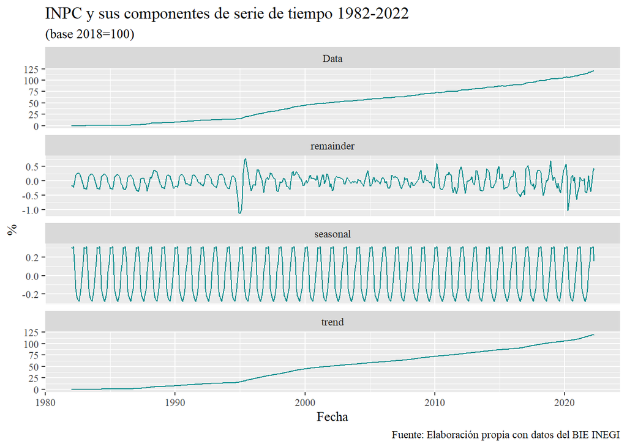

```r
# El siguiente comando descompone de manera gráfica la serie y sus componentes
ggplot2::autoplot(stl(Indice_mensual_ts, "periodic"), ts.colour = "cyan4") +
     labs(title = "INPC y sus componentes de serie de tiempo 1982-2022",
          subtitle = "(base 2018=100)",
          x = "Fecha",
          y = "%",
          caption = "Fuente: Elaboración propia con datos del BIE INEGI") +
     theme_gray(base_family = "serif")
```

A hora podemos eliminar la tendencia de la serie y observar cómo se comporta.

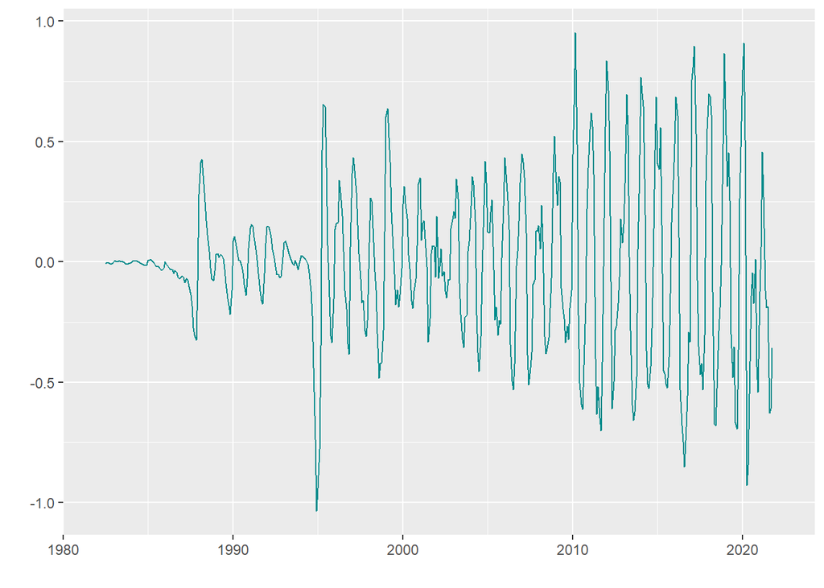

```r
ntrend_inpc <- Indice_mensual_ts - trend_inpc
autoplot(ntrend_inpc, colour = "cyan4")
```

# 7. Filtro Hodrick - Prescott

Para utilizar el filtro *Hodrick-Prescott* empleamos la paquetería `mFilter`. Establecemos el valor lambda $\lambda = 120000$ que se encuentra en el rango propuesto por [Maravall y del Rio (2001)](https://www.bde.es/f/webbde/SES/Secciones/Publicaciones/PublicacionesSeriadas/DocumentosTrabajo/01/Fic/dt0108e.pdf) para datos de frecuencia mensual.

Obtenemos el componente cíclico de la serie con el filtro Hodrick-Prescott de la siguiente manera:

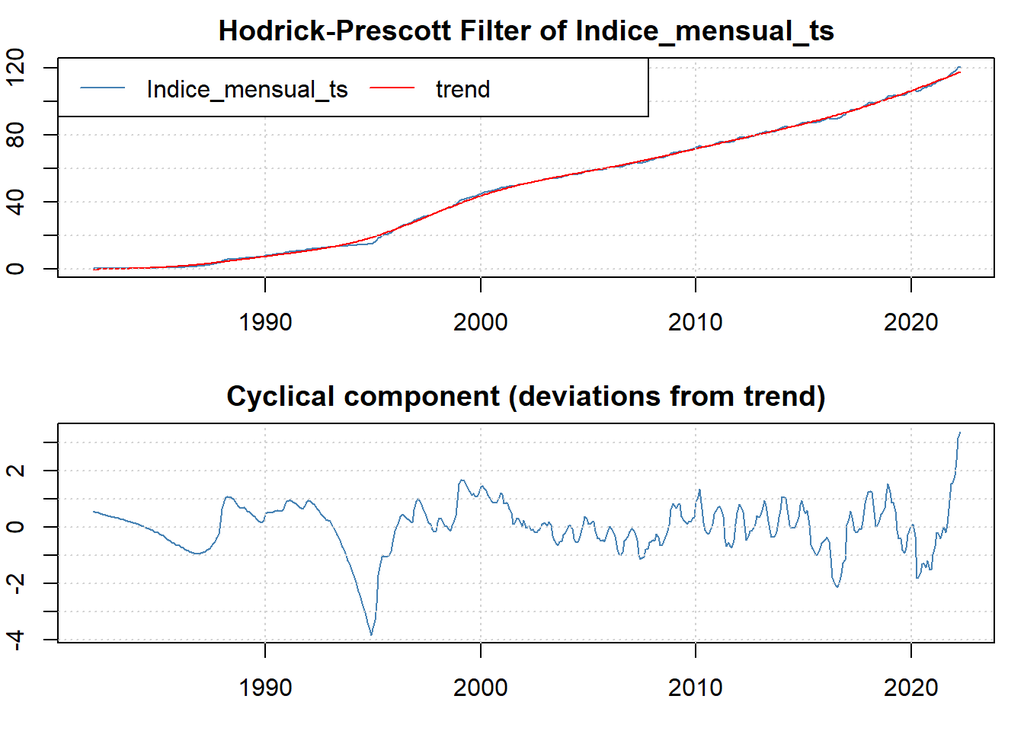

```r
lambda_hp1 <- 120000
INPC_HP <- hpfilter(Indice_mensual_ts, type = "lambda", freq = lambda_hp1)
plot(INPC_HP)
```

# 8. Prueba de raices unitarias

## 8.1 Augmented Dickey-Fuller (ADF) test

La hipótesis nula del test ADF es la no estacionariedad, si rechazamos $H_o$ entonces nuestra sere es estacionaria. Realizaremos el test para las series `Indice_mensual_ts`, `Inflación_mensual` e `Inflacion_mensual_inter`

```r
aTSA::adf.test(Indice_mensual_ts)
```

```
## Augmented Dickey-Fuller Test
## alternative: stationary
##
## Type 1: no drift no trend
##      lag   ADF p.value
## [1,]   0 20.02    0.99
## [2,]   1  7.00    0.99
## [3,]   2  6.70    0.99
## [4,]   3  6.16    0.99
## [5,]   4  5.86    0.99
## [6,]   5  6.15    0.99
## Type 2: with drift no trend
##      lag  ADF p.value
## [1,]   0 7.01    0.99
## [2,]   1 3.27    0.99
## [3,]   2 3.31    0.99
## [4,]   3 3.21    0.99
## [5,]   4 3.20    0.99
## [6,]   5 3.53    0.99
## Type 3: with drift and trend
##      lag   ADF p.value
## [1,]   0 -2.20   0.493
## [2,]   1 -1.93   0.605
## [3,]   2 -1.92   0.610
## [4,]   3 -1.91   0.615
## [5,]   4 -1.90   0.620
## [6,]   5 -1.91   0.616
## ----
## Note: in fact, p.value = 0.01 means p.value <= 0.01
```

```r
aTSA::adf.test(Inflacion_mensual)
```

```
## Augmented Dickey-Fuller Test
## alternative: stationary
##
## Type 1: no drift no trend
##      lag   ADF p.value
## [1,]   0 -4.86  0.0100
## [2,]   1 -4.43  0.0100
## [3,]   2 -3.59  0.0100
## [4,]   3 -3.18  0.0100
## [5,]   4 -2.97  0.0100
## [6,]   5 -2.89  0.0100
## [7,]   6 -2.50  0.0134
## Type 2: with drift no trend
##      lag   ADF p.value
## [1,]   0 -6.12  0.0100
## [2,]   1 -5.66  0.0100
## [3,]   2 -4.61  0.0100
## [4,]   3 -4.12  0.0100
## [5,]   4 -3.87  0.0100
## [6,]   5 -3.77  0.0100
## [7,]   6 -3.28  0.0178
## Type 3: with drift and trend
##      lag   ADF p.value
## [1,]   0 -6.71  0.0100
## [2,]   1 -6.27  0.0100
## [3,]   2 -5.15  0.0100
## [4,]   3 -4.65  0.0100
## [5,]   4 -4.40  0.0100
## [6,]   5 -4.29  0.0100
## [7,]   6 -3.79  0.0192
## ----
## Note: in fact, p.value = 0.01 means p.value <= 0.01
```

```r
aTSA::adf.test(Inflacion_mensual_inter)
```

```
## Augmented Dickey-Fuller Test
## alternative: stationary
##
## Type 1: no drift no trend
##      lag    ADF p.value
## [1,]   0 -0.933   0.345
## [2,]   1 -2.609   0.010
## [3,]   2 -2.693   0.010
## [4,]   3 -2.860   0.010
## [5,]   4 -2.906   0.010
## [6,]   5 -2.887   0.010
## [7,]   6 -2.728   0.010
## Type 2: with drift no trend
##      lag   ADF p.value
## [1,]   0 -1.17  0.6404
## [2,]   1 -3.24  0.0197
## [3,]   2 -3.35  0.0145
## [4,]   3 -3.57  0.0100
## [5,]   4 -3.64  0.0100
## [6,]   5 -3.63  0.0100
## [7,]   6 -3.44  0.0100
## Type 3: with drift and trend
##      lag   ADF p.value
## [1,]   0 -1.57  0.7588
## [2,]   1 -3.61  0.0306
## [3,]   2 -3.73  0.0221
## [4,]   3 -3.98  0.0100
## [5,]   4 -4.06  0.0100
## [6,]   5 -4.06  0.0100
## [7,]   6 -3.87  0.0149
## ----
## Note: in fact, p.value = 0.01 means p.value <= 0.01
```

Los resultados del test nos indícan que el INPC mensual no es estacionario en niveles, mientras que la inflación mensual y la inflación interanual si lo son al presentar, para estas últimas, un $p-value < 0.5$.

Obtenemos las primeras diferencias de la serie del INPC y realizamos nuevamente el test ADF.

```r
d1_INPC_mensual <- diff(Indice_mensual_ts, lag = 12, differences = 1)
adf.test(d1_INPC_mensual)
```

```
## Augmented Dickey-Fuller Test
## alternative: stationary
##
## Type 1: no drift no trend
##      lag     ADF p.value
## [1,]   0  1.1342   0.931
## [2,]   1 -0.0523   0.629
## [3,]   2  0.0565   0.660
## [4,]   3 -0.0184   0.639
## [5,]   4  0.0281   0.652
## [6,]   5 -0.0905   0.618
## Type 2: with drift no trend
##      lag    ADF p.value
## [1,]   0 -0.343   0.913
## [2,]   1 -1.712   0.443
## [3,]   2 -1.584   0.494
## [4,]   3 -1.695   0.450
## [5,]   4 -1.650   0.467
## [6,]   5 -1.828   0.396
## Type 3: with drift and trend
##      lag    ADF p.value
## [1,]   0 -0.894   0.953
## [2,]   1 -2.298   0.450
## [3,]   2 -2.159   0.509
## [4,]   3 -2.278   0.459
## [5,]   4 -2.229   0.479
## [6,]   5 -2.419   0.399
## ----
## Note: in fact, p.value = 0.01 means p.value <= 0.01
```

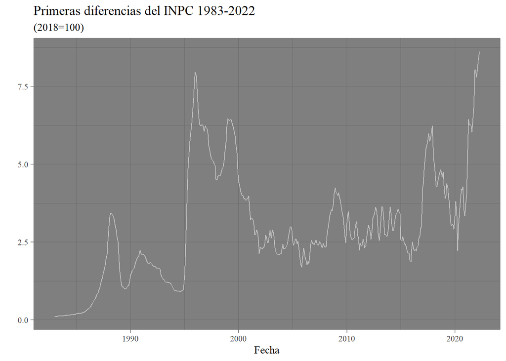

```r
ggplot2::autoplot(d1_INPC_mensual, ts.colour = "gray") +
  labs(title = "Primeras diferencias del INPC 1983-2022",
       subtitle = "(2018=100)",
       x = "Fecha") +
  theme_dark(base_family = "serif")
```

Nuevamente la serie no es estacionaria, obtenemos las segundas diferencias.

```r
d2_INPC_mensual <- diff(Indice_mensual_ts, lag = 12, differences = 2)
adf.test(d2_INPC_mensual)
```

```
## Augmented Dickey-Fuller Test
## alternative: stationary
##
## Type 1: no drift no trend
##      lag   ADF p.value
## [1,]   0 -2.95    0.01
## [2,]   1 -5.04    0.01
## [3,]   2 -4.72    0.01
## [4,]   3 -4.90    0.01
## [5,]   4 -4.73    0.01
## [6,]   5 -4.80    0.01
## Type 2: with drift no trend
##      lag   ADF p.value
## [1,]   0 -3.00  0.0374
## [2,]   1 -5.09  0.0100
## [3,]   2 -4.77  0.0100
## [4,]   3 -4.95  0.0100
## [5,]   4 -4.78  0.0100
## [6,]   5 -4.86  0.0100
## Type 3: with drift and trend
##      lag   ADF p.value
## [1,]   0 -3.02   0.147
## [2,]   1 -5.09   0.010
## [3,]   2 -4.77   0.010
## [4,]   3 -4.95   0.010
## [5,]   4 -4.78   0.010
## [6,]   5 -4.85   0.010
## ----
## Note: in fact, p.value = 0.01 means p.value <= 0.01
```

La serie del INPC de 1983 a 2022 es estacionaria en sus segundas diferencias, es decir, es I(2), mientras que la inflación mensual y la inflación interanual son I(0).

## 8.2 Phillips-Perron test

```r
aTSA::pp.test(Indice_mensual_ts)
```

```
## Phillips-Perron Unit Root Test
## alternative: stationary
##
## Type 1: no drift no trend
##  lag Z_rho p.value
##    5     2   0.989
## -----
##  Type 2: with drift no trend
##  lag Z_rho p.value
##    5   1.1    0.99
## -----
##  Type 3: with drift and trend
##  lag Z_rho p.value
##    5 -4.15   0.871
## ---------------
## Note: p-value = 0.01 means p.value <= 0.01
```

```r
aTSA::pp.test(Inflacion_mensual)
```

```
## Phillips-Perron Unit Root Test
## alternative: stationary
##
## Type 1: no drift no trend
##  lag Z_rho p.value
##    6 -30.3    0.01
## -----
##  Type 2: with drift no trend
##  lag Z_rho p.value
##    6 -54.3    0.01
## -----
##  Type 3: with drift and trend
##  lag Z_rho p.value
##    6 -67.4    0.01
## ---------------
## Note: p-value = 0.01 means p.value <= 0.01
```

```r
aTSA::pp.test(Inflacion_mensual_inter)
```

```
## Phillips-Perron Unit Root Test
## alternative: stationary
##
## Type 1: no drift no trend
##  lag Z_rho p.value
##    6 -7.67  0.0577
## -----
##  Type 2: with drift no trend
##  lag Z_rho p.value
##    6 -11.7  0.0919
## -----
##  Type 3: with drift and trend
##  lag Z_rho p.value
##    6 -14.3    0.27
## ---------------
## Note: p-value = 0.01 means p.value <= 0.01
```

Con el test de Phillips-Perron sólo la serie de `Inflacion_mensual` no presenta raíz unitaria, es I(0). Realizamos la prueba para las diferencias de la `Inflacion_mensual_inter` y para el `Indice_mensual_ts`.

```r
d1_Inf_inter <- diff(Inflacion_mensual_inter, lag = 12, differences = 1)
aTSA::pp.test(d1_Inf_inter)
```

```
## Phillips-Perron Unit Root Test
## alternative: stationary
##
## Type 1: no drift no trend
##  lag Z_rho p.value
##    6 -48.7    0.01
## -----
##  Type 2: with drift no trend
##  lag Z_rho p.value
##    6 -48.7    0.01
## -----
##  Type 3: with drift and trend
##  lag Z_rho p.value
##    6 -48.8    0.01
## ---------------
## Note: p-value = 0.01 means p.value <= 0.01
```

```r
aTSA::pp.test(d1_INPC_mensual)
```

```
## Phillips-Perron Unit Root Test
## alternative: stationary
##
## Type 1: no drift no trend
##  lag Z_rho p.value
##    5 0.453   0.793
## -----
##  Type 2: with drift no trend
##  lag Z_rho p.value
##    5 -6.26   0.388
## -----
##  Type 3: with drift and trend
##  lag Z_rho p.value
##    5 -10.1   0.454
## ---------------
## Note: p-value = 0.01 means p.value <= 0.01
```

```r
aTSA::pp.test(d2_INPC_mensual)
```

```
## Phillips-Perron Unit Root Test
## alternative: stationary
##
## Type 1: no drift no trend
##  lag Z_rho p.value
##    5 -35.1    0.01
## -----
##  Type 2: with drift no trend
##  lag Z_rho p.value
##    5 -35.8    0.01
## -----
##  Type 3: with drift and trend
##  lag Z_rho p.value
##    5 -35.9    0.01
## ---------------
## Note: p-value = 0.01 means p.value <= 0.01
```

Obtenemos que la serie de `Inflacion_mensual_inter` es I(1) y la de `Indice_mensual_ts` es I(2).

# 9. Modelos ARIMA

$ARIMA$ significa AutoRegressive Integrated Moving Average. El término autorregresivo se refiere a los retrasos de la serie diferenciada (AR), el término de media movil (MA) se refiere a los retrasos de los errores, y el número de diferencias necesarias para hacer la serie estacionaria es la I (AR, I, MA). Un modelo o proceso $ARIMA$ es aquel que modela directamente la autocorrelación de los valores de la serie así como las autocorrelaciones de los errores del pronóstico.

Realizaremos procesos ARIMA para las series `Inflacion_mensual`,`Inflacion_mensual_inter` e `Indice_mensual_ts`. Para estimar un ARIMA es necesario que las series sean estacionarias.

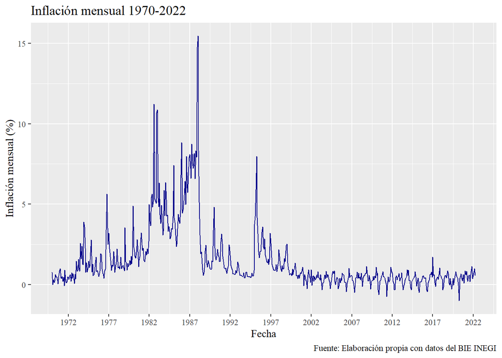

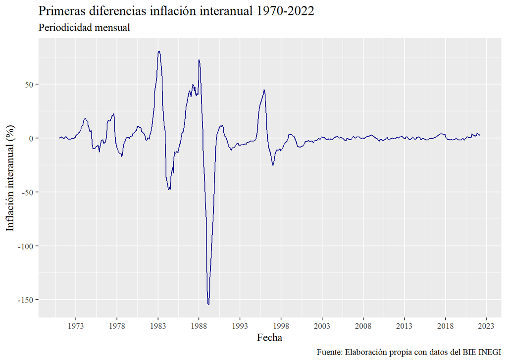

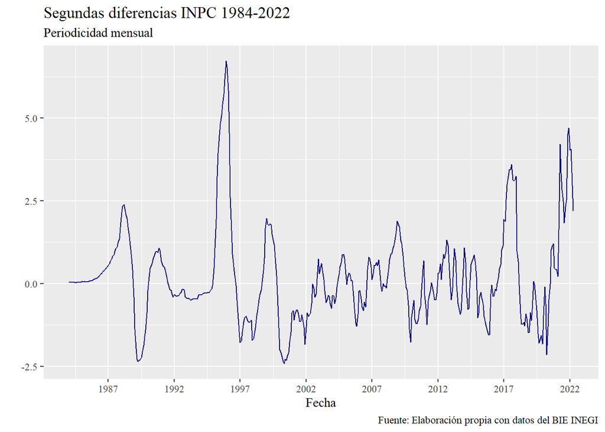

```r
AR_1 <- auto.arima(Inflacion_mensual)
AR_2 <- auto.arima(d1_Inf_inter)
AR_2_2 <- auto.arima(Inflacion_mensual_inter)
AR_3 <- auto.arima(d2_INPC_mensual)
summary(AR_1)
```

```
## Series: Inflacion_mensual
## ARIMA(4,1,1)(0,0,2)[12]
##
## Coefficients:
##          ar1      ar2     ar3     ar4      ma1    sma1    sma2
##       0.7744  -0.0610  0.0779  0.0659  -0.9827  0.1449  0.2136
## s.e.  0.0418   0.0506  0.0504  0.0410   0.0127  0.0402  0.0360
##
## sigma^2 = 0.7534:  log likelihood = -798.29
## AIC=1612.58   AICc=1612.82   BIC=1648.11
##
## Training set error measures:
##                        ME      RMSE      MAE MPE MAPE      MASE        ACF1
## Training set -0.001530141 0.8624144 0.476979 NaN  Inf 0.5499346 7.08561e-05
```

```r
summary(AR_2)
```

```
## Series: d1_Inf_inter
## ARIMA(5,0,0)(2,0,0)[12] with zero mean
##
## Coefficients:
##          ar1      ar2      ar3     ar4      ar5     sar1    sar2
##       1.6961  -0.6680  -0.0285  0.0905  -0.1071  -1.0235  -0.500
## s.e.  0.0400   0.0792   0.0838  0.0793   0.0400   0.0346   0.034
##
## sigma^2 = 3.772:  log likelihood = -1289.55
## AIC=2595.11   AICc=2595.34   BIC=2630.49
##
## Training set error measures:
##                        ME     RMSE      MAE MPE MAPE       MASE        ACF1
## Training set 0.0007632662 1.931212 1.017588 Inf  Inf 0.06071491 0.006360127
```

```r
summary(AR_2_2)
```

```
## Series: Inflacion_mensual_inter
## ARIMA(1,1,0)(0,0,2)[12]
##
## Coefficients:
##          ar1     sma1    sma2
##       0.8416  -0.7770  0.1005
## s.e.  0.0219   0.0423  0.0410
##
## sigma^2 = 2.06:  log likelihood = -1119.45
## AIC=2246.9   AICc=2246.96   BIC=2264.66
##
## Training set error measures:
##                       ME     RMSE      MAE        MPE     MAPE       MASE
## Training set 0.001147752 1.430538 0.702441 -0.2356406 4.411593 0.06453197
##                     ACF1
## Training set -0.01903975
```

```r
summary(AR_3)
```

```
## Series: d2_INPC_mensual
## ARIMA(2,0,0)(2,0,0)[12] with zero mean
##
## Coefficients:
##          ar1      ar2     sar1     sar2
##       1.4869  -0.5027  -0.9992  -0.5133
## s.e.  0.0412   0.0413   0.0440   0.0460
##
## sigma^2 = 0.06609:  log likelihood = -34.55
## AIC=79.11   AICc=79.24   BIC=99.76
##
## Training set error measures:
##                      ME      RMSE       MAE     MPE    MAPE     MASE
## Training set 0.01143343 0.2559662 0.1560038 3024909 3024941 0.102017
##                      ACF1
## Training set 0.0002452001
```

Para probar si el modelo se ajusta bien realizamos la prueba de Box-Ljung

```r
Box.test(residuals(AR_1), type = "Ljung-Box")
```

```
##
##  Box-Ljung test
##
## data:  residuals(AR_1)
## X-squared = 3.168e-06, df = 1, p-value = 0.9986
```

```r
Box.test(residuals(AR_2), type = "Ljung-Box")
```

```
##
##  Box-Ljung test
##
## data:  residuals(AR_2)
## X-squared = 0.02504, df = 1, p-value = 0.8743
```

```r
Box.test(residuals(AR_2_2), type = "Ljung-Box")
```

```
##
##  Box-Ljung test
##
## data:  residuals(AR_2_2)
## X-squared = 0.22875, df = 1, p-value = 0.6325
```

```r
Box.test(residuals(AR_3), type = "Ljung-Box")
```

```
##
##  Box-Ljung test
##
## data:  residuals(AR_3)
## X-squared = 2.7837e-05, df = 1, p-value = 0.9958
```

Para todos los casos, el test al presentar un $p-value > 0.05$, nos indica que existe ruido blanco: media igual a cero, varianza constante y no está serialmente correlacion serial.

# 10. Pronósticos

Realizaremos pronósticos con los modelos de tendencia lineal y cuadrática, y con los modelos $ARIMA$

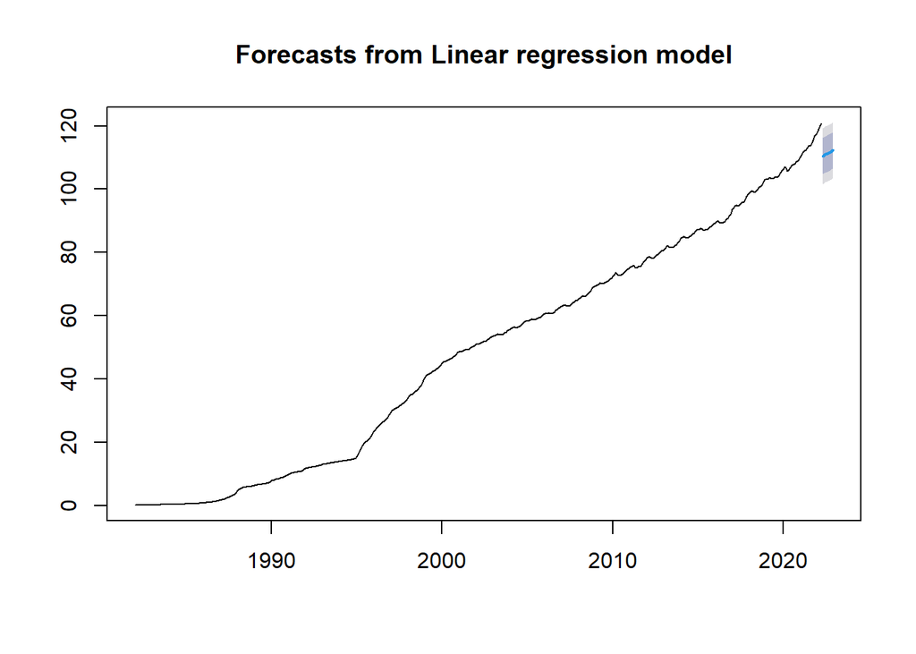

```r
pro_tl <- forecast::forecast(m_tl, h = 8)
pro_tc <- forecast::forecast(m_tc, h = 8)
plot(pro_tl)
```

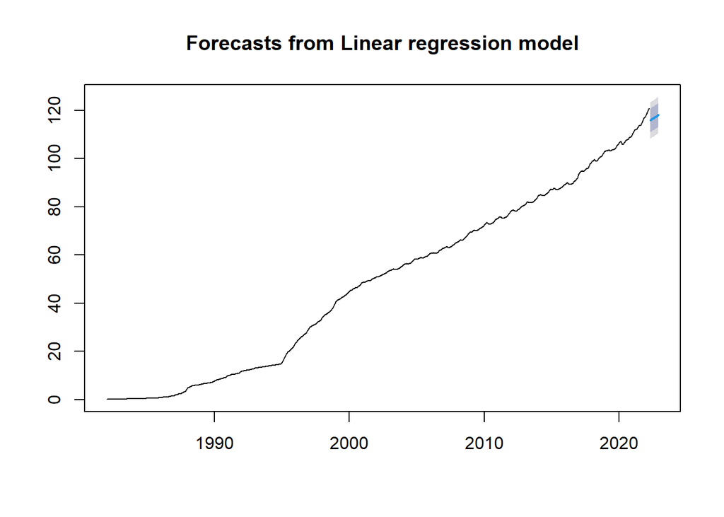

```r
plot(pro_tc)
```

```r
pro_AR1 <- forecast::forecast(AR_1, h =8)
pro_AR2 <- forecast::forecast(AR_2, h =8)
pro_AR2_2 <- forecast::forecast(AR_2_2, h =8)
pro_AR3 <- forecast::forecast(AR_3, h =8)
tail(Inflacion_mensual, n = 12)
```

```
##       Jan  Feb  Mar  Apr  May  Jun  Jul  Aug  Sep  Oct  Nov  Dec
## 2021                     0.20 0.53 0.59 0.19 0.62 0.84 1.14 0.36
## 2022 0.59 0.83 0.99 0.54
```

```r
pro_AR1
```

```
##          Point Forecast      Lo 80    Hi 80      Lo 95    Hi 95
## May 2022      0.7200557 -0.3922805 1.832392 -0.9811157 2.421227
## Jun 2022      0.7590841 -0.6596849 2.177853 -1.4107359 2.928904
## Jul 2022      0.7646402 -0.7890998 2.318380 -1.6116001 3.140880
## Aug 2022      0.6557895 -0.9900074 2.301586 -1.8612396 3.172819
## Sep 2022      0.6500731 -1.0829369 2.383083 -2.0003370 3.300483
## Oct 2022      0.7225064 -1.0851045 2.530117 -2.0419959 3.487009
## Nov 2022      0.6306750 -1.2365833 2.497933 -2.2250501 3.486400
## Dec 2022      0.5730222 -1.3427823 2.488827 -2.3569479 3.502992
```

```r
tail(d1_Inf_inter, n = 12)
```

```
##       Jan  Feb  Mar  Apr  May  Jun  Jul  Aug  Sep  Oct  Nov  Dec
## 2021                     3.05 2.55 2.19 1.54 1.99 2.15 4.04 4.21
## 2022 3.53 3.52 2.78 1.60
```

```r
pro_AR2
```

```
##          Point Forecast        Lo 80     Hi 80      Lo 95     Hi 95
## May 2022      2.4590690  -0.03006153  4.948200  -1.347728  6.265866
## Jun 2022      2.7963619  -2.10458737  7.697311  -4.698993 10.291717
## Jul 2022      3.0858481  -4.27932450 10.451021  -8.178211 14.349908
## Aug 2022      3.3292899  -6.45028304 13.108863 -11.627276 18.285856
## Sep 2022      2.8415181  -9.38910215 15.072138 -15.863601 21.546638
## Oct 2022      2.6120600 -12.06797430 17.292094 -19.839115 25.063235
## Nov 2022      0.9356211 -16.14206193 18.013304 -25.182441 27.053684
## Dec 2022      0.6332228 -18.74645913 20.012905 -29.005443 30.271889
```

```r
tail(Inflacion_mensual_inter, n = 12)
```

```
##       Jan  Feb  Mar  Apr  May  Jun  Jul  Aug  Sep  Oct  Nov  Dec
## 2021                     5.89 5.88 5.81 5.59 6.00 6.24 7.37 7.36
## 2022 7.07 7.28 7.45 7.68
```

```r
pro_AR2
```

```
##          Point Forecast        Lo 80     Hi 80      Lo 95     Hi 95
## May 2022      2.4590690  -0.03006153  4.948200  -1.347728  6.265866
## Jun 2022      2.7963619  -2.10458737  7.697311  -4.698993 10.291717
## Jul 2022      3.0858481  -4.27932450 10.451021  -8.178211 14.349908
## Aug 2022      3.3292899  -6.45028304 13.108863 -11.627276 18.285856
## Sep 2022      2.8415181  -9.38910215 15.072138 -15.863601 21.546638
## Oct 2022      2.6120600 -12.06797430 17.292094 -19.839115 25.063235
## Nov 2022      0.9356211 -16.14206193 18.013304 -25.182441 27.053684
## Dec 2022      0.6332228 -18.74645913 20.012905 -29.005443 30.271889
```

```r
tail(d2_INPC_mensual, n = 12)
```

```
##        Jan   Feb   Mar   Apr   May   Jun   Jul   Aug   Sep   Oct   Nov   Dec
## 2021                         3.328 2.831 2.481 1.835 2.315 2.516 4.518 4.700
## 2022 4.029 4.056 3.349 2.184
```

```r
pro_AR3
```

```
##          Point Forecast      Lo 80    Hi 80       Lo 95    Hi 95
## May 2022      2.8693147  2.5398452 3.198784  2.36543458 3.373195
## Jun 2022      2.9701972  2.3798269 3.560568  2.06730364 3.873091
## Jul 2022      3.0128274  2.1971928 3.828462  1.76542188 4.260233
## Aug 2022      3.0016209  1.9946526 4.008589  1.46159572 4.541646
## Sep 2022      2.3098323  1.1401393 3.479525  0.52094120 4.098723
## Oct 2022      1.9216673  0.6124723 3.230862 -0.08057364 3.923908
## Nov 2022      0.1433206 -1.2866594 1.573301 -2.04364517 2.330286
## Dec 2022     -0.1729582 -1.7085494 1.362633 -2.52144225 2.175526
```

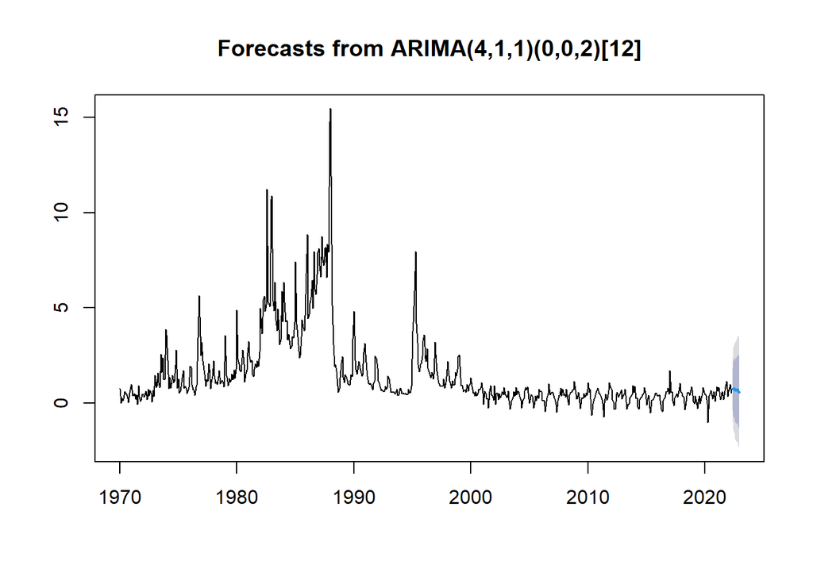

```r
plot(pro_AR1)
```

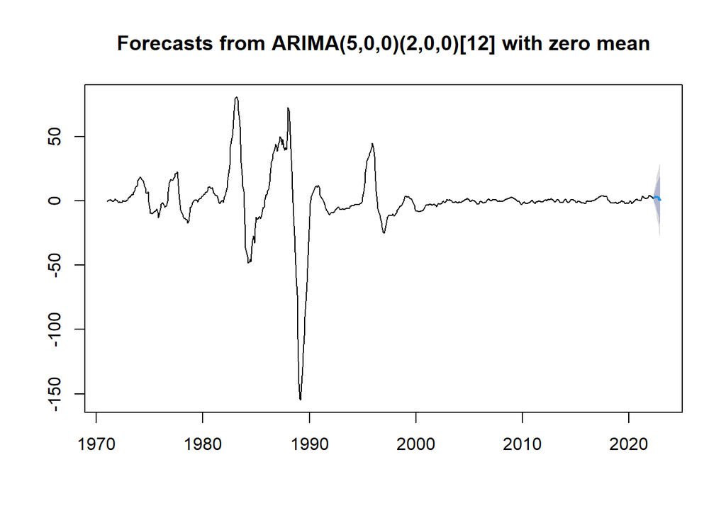

```r
plot(pro_AR2)
```

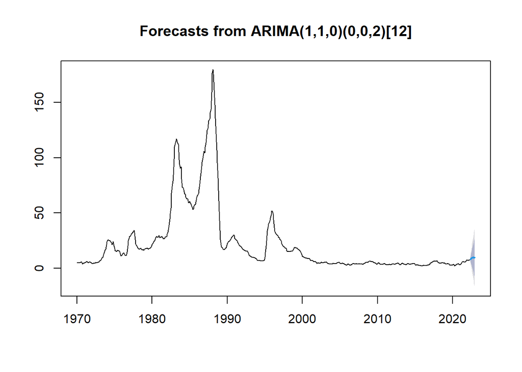

```r
plot(pro_AR2_2)
```

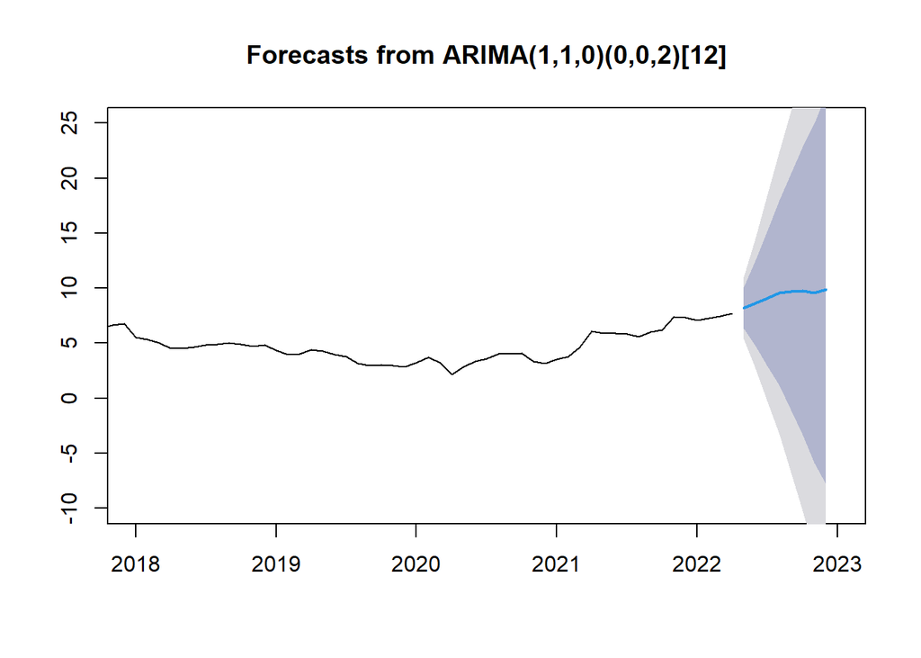

```r
plot(pro_AR2_2, xlim = c(2018, 2023), ylim = c(-10, 25))
```

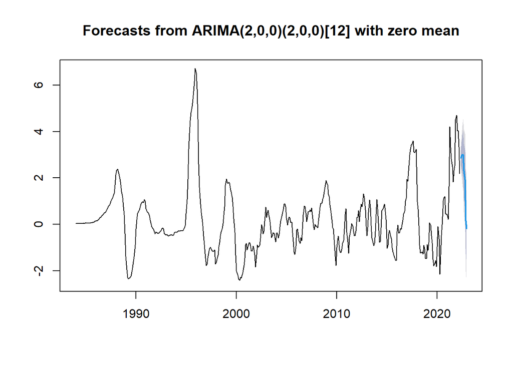

```r
plot(pro_AR3)
```